# Өгөгдлийг цэвэрлэх ба үндсэн функцууд

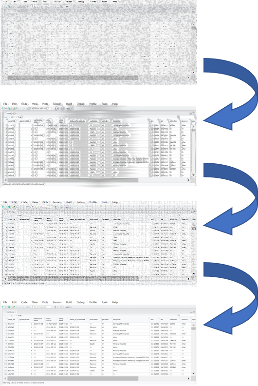

Энэ бүлэгт датаг “цэвэрлэх” нийтлэг аргуудыг үзэж R-ын дата менежментэд хэрэглэгддэг гол функцуудыг тайлбарлана.

Дата цэвэрлэгээг тайлбарлахдаа түүхий (raw) linelist -ийг импортлохоос эхлээд хэрхэн цэвэрлэгээ хийж буйг нэг бүрчлэн үзүүлэх болно. R- дээр дата “pipe (хоолой)” залгагдсан холбоосоор дамжин хийгддэг ба датаг нэгээс нөгөөрүү дамжуулах үйлдлийг “pipe” `%>%` буюу холбогч оператор гүйцэтгэдэг.

### Үндсэн функцууд

Энэхүү номонд [**tidyverse**](https://www.tidyverse.org/) бүлгийн харяа багцууд, тэдгээрийн функцыг голчлон тайлбарлна. Гол хэрэглэгдэх функцуудыг дор жагсаав.

Үүнд [**dplyr**](https://dplyr.tidyverse.org/) багцын дата засаж, янзалдаг “үйл үгэн” функцууд түлхүү орсон (**dplyr** багцын нэр “data frame-plier буюу”хүснэгт засагч" гэсэн утгатай). **dplyr** бол **tidyverse** -ын харьяа багц ( **tidyverse** –ын бусад багцуудад **ggplot2**,**tidyr**,**stringr**,**tibble**,**purrr**,**magrittr**,**forcats** ордог).

Function

Utility

Package

`%>%`

“pipe” (дамжуулах) датаг нэг функцээс нөгөөд дамжуулна

[output not shown]

`mutate()`

`select()`

Баганыг үлдээх, арилгах, шинээр нэр өгдөг

| **dplyr**

`rename()`

Баганыг шинээр нэрлэдэг

[output not shown]

`clean_names()`

`as.character()`, `as.numeric()`, `as.Date()`, etc.

Баганадах өгөгдлийн төрлийг өөрчилнө.

| **base** R

`across()`

Олон баганыг зэрэг хувиргана | **dplyr**

**tidyselect** functions

Баганыг сонгохдоо logic ашиглаган

[output not shown]

`filter()`

Тодорхой мөрүүдийг авч үлдэх

[output not shown]

`distinct()`

Мөрүүдийг давхардалтыг арилгах

[output not shown]

`rowwise()`

`add_row()`

Мөрийг гар аргаар нэмэх

| **tibble**

`arrange()`

Мөрийг эрэмбэлэх

[output not shown]

`recode()`

Баганадах утгыг дахин өгөх |

**dplyr**

`case_when()`

`replace_na()`, `na_if()`, `coalesce()`

Баганад утга өгөх тусгай функцууд

**tidyr**

`age_categories()` and `cut()`

`clean_variable_spelling()`

`which()`

Логик шалгуур ашиглах; Индексийг харуулах (return indices)

[output not shown]

Эдгээр функцууд Stata болон SAS программ дээр хэрхэн бичигддэг талаар [Transition to R] –линкээс үзэж болно.

Датаг янзалж байхад R-ын **data.table** багцын операторууд `:=` болон `[ ]`-ыг олж харах магадлалтай. **data.table** багцын хэрэглэгддэг синтакс, аргачлалыг [Data Table] хуудаст товч оруулсан.

### Нэр томьёо

Энэ номонд хувьсагч (variable) -ийг багана, ажиглалт (observations) -ийг мөр гэж нэрших болно. Тархвар судлалын ихэнх датаг гол бүрдүүлдэг зүйлс бол багана, мөр, доторх утгууд гэж [“tidy data”](https://tidyr.tidyverse.org/articles/tidy-data.html) “tidy data” линкэд тайлбарласан байна.

*Хувьсагч (Variables)* нь ижил хэв шинжтэй утгуудыг агуулсан байдаг (насны бүлэг, өвчин эхэлсэн огноо, эмчилгээний үр дүн гэх мэт ). *Ажиглалт (Observations)* гэж тухайн нэгжийн бүх төрлийн хэмжилтүүдийг хэлнэ (хүн, газар, лабораторийн дээж материал). Эдгээр шинж талуудыг бодитоор, барьцтай илэрхийлэх нь бэрхшээлтэй.

“Tidy/Цэгцтэй” өгөгдөлд, багана болгон хувьсагч, мөр болгон ажиглалт ба нэг нүд болгон нэг утгыг зааж байдаг. Заримдаа энэ загварт хэлбэржээгүй дататай та учирч болох юм. Тухайлбал " wide(өргөн)" дата гэхэд хувьсагч нь хэд хэдэн баганад хуваагдан байрладаг. Үүний жишээг [Pivoting data]–т хэсэгт жишээг харуулсан. Ажиглалт ч гэсэн хэд хэдэн мөрөнд хуваагдан байрласан байх тохиолдол бий.

Энэ номоороо бид датаг хэрхэн хувиргаж, янзлах, менежмент хийдгийг харуулахыг илүү эрмэлзсэн . Тийм ч учраас хувьсагч, ажиглалт зэрэг хийсвэр тодорхойлолт хэрэглэхийн оронд мөр, багана зэрэг бүтцийн нь нэршилийг хэрэглэх нь илүү тохиромжтой гэж үзсэн. Харин статистик дүн шинжилгээний талаар тайлбарласан хэсгүүдэд хувьсагч, ажиглалт гэсэн нэршил илүү хэрэглэгдсэн.

## Цэвэрлэх холбоос

**Энэ хэсэгт датаг цэвэрлэгээг үе шат тус бүрээр нь тайлбарласан. Цэвэрлэгээний явцыг нэг бүрчлэн “pipe” цэвэрлэх холбоост залгаж үзүүлсэн.**

Тархвар судлалд датаг янзлах, цэвэрлэх явц хоорондоо холбоотой дараалласан үйлдлүүдээс бүрддэг. R программ дээр цэвэрлэгээг хийхдээ мөн адил *датаг нэг цэвэрлэх шатнаас нөгөөд угсруулан үйлддэг.*

Ийм угсруулсан үйлдлүүдийг **dplyr** –ын “үйл үгт” функцуууд болон **magrittr**-ын pipe`%>%` холбогч оператор хамтран гүйцэтгэдэг. Цэвэрлэгээ түүхий датагаар (“linelist_raw.xlsx”) эхлээд R –ын “цэвэрхэн” хүснэгт (`linelist`) болж хувиран гардаг. Үүнийг шууд ашиглаж, хадгалж, экспортлож болно.

Цэвэрлэгээ хийж байхад үйлдлийн дараалал чухал. Дараах дарааллаар хийх нь элбэг:

- Датаг оруулж ирэх
- Баганын нэрсийг өөрчлөх, арилгах
- Давхардсан утгуудыг арилгах
- Багана нэмж, хувиргах (утгыг хувиргах, )Column creation and transformation (баганадах утгыг хувиргах, утгыг стандардчилах гэх мэт)
- Мөрүүдийг шүүж хасаж, нэмэх

## Багцуудыг ачааллах

Доорх кодыг уншуулж шаардлагатай багцуудыг ачааллана. Энэ номонд багцыг ачааллахад **pacman** -ны `p_load()`-ыг голчлон хэрэглэ. Энэ функц нь шаардлагатай багцыг автоматаар татаж авч, ачааллаад ажиллахад бэлэн болгодог. **base** R-ын багцыг `library()`–аар та өөрөө шууд (татаж авалгүйгээр )ачааллаж бас болно. [R basics] хэсгээс талаар нэмж үзнэ үү.

```r
pacman::p_load(
  rio,        # дата оруулах
  here,       # файлын холбоотой замыг тогтоох
  janitor,    # дата, хүснэгт цэвэрлэх
  lubridate,  # огноотой ажиллах
  epikit,     # age_categories() функц
  tidyverse   # дата менежмент ба график зураглал
)
```

## Датаг импортлох

### Импорт хийх

Түүхий дата агуулсан Excel файлыг **rio**-ын `import()` функцээр импортлоно. **Rio** багц файл ын олон төрөлтэй ажиллаж чаддагаараа онцлог (.xlsx, .csv, .tsv, .rds. гэх мэт). [Import and export] хэсгээс дэлгэрүүлж үзнэ үү.

Хэрэв хамт дасгалыг зэрэг хийхийг хүсвэл энэ линкээр датаг татаж авна уу. [линк дээр дарж “түүхий” linelist -ыг татаж ав](https://github.com/epirhandbook/Epi_R_handbook/raw/master/data/case_linelists/linelist_raw.xlsx) ( .xlsx файл).

If your dataset is large and takes a long time to import, it can be useful to have the import command be separate from the pipe chain and the “raw” saved as a distinct file. This also allows easy comparison between the original and cleaned versions.

Below we import the raw Excel file and save it as the data frame `linelist_raw`. We assume the file is located in your working directory or R project root, and so no sub-folders are specified in the file path.

```r
linelist_raw <- import("linelist_raw.xlsx")
```

You can view the first 50 rows of the the data frame below. Note: the **base** R function `head(n)` allow you to view just the first `n` rows in the R console.

| case_id | generation | infection date | date onset | hosp date | date_of_outcome | outcome | gender | hospital | lon | lat | infector | source | age | age_unit | row_num | wt_kg | ht_cm | ct_blood | fever | chills | cough | aches | vomit | temp | time_admission | merged_header | ...28 |
| --- | --- | --- | --- | --- | --- | --- | --- | --- | --- | --- | --- | --- | --- | --- | --- | --- | --- | --- | --- | --- | --- | --- | --- | --- | --- | --- | --- |
| 5fe599 | 4 | 2014-05-08T00:00:00Z | 2014-05-13 | 2014-05-15T00:00:00Z |  |  | m | Other | -13.2157351064963 | 8.46897295100924 | f547d6 | other | 2 | years | 1 | 27 | 48 | 22 | no | no | yes | no | yes | 36.8 |  | a | b |
| 8689b7 | 4 |  | 2014-05-13 | 2014-05-14T00:00:00Z | 2014-05-18T00:00:00Z | Recover | f |  | -13.2152339775486 | 8.45171855856465 |  |  | 3 | years | 2 | 25 | 59 | 22 |  |  |  |  |  | 36.9 | 09:36 | a | b |
| 11f8ea | 2 |  | 2014-05-16 | 2014-05-18T00:00:00Z | 2014-05-30T00:00:00Z | Recover | m | St. Mark's Maternity Hospital (SMMH) | -13.212910703914 | 8.46481700596819 |  |  | 56 | years | 3 | 91 | 238 | 21 |  |  |  |  |  | 36.9 | 16:48 | a | b |
| b8812a | 3 | 2014-05-04T00:00:00Z | 2014-05-18 | 2014-05-20T00:00:00Z |  |  | f | Port Hospital | -13.2363711169728 | 8.4754761613651 | f90f5f | other | 18 | years | 4 | 41 | 135 | 23 | no | no | no | no | no | 36.8 | 11:22 | a | b |
| 893f25 | 3 | 2014-05-18T00:00:00Z | 2014-05-21 | 2014-05-22T00:00:00Z | 2014-05-29T00:00:00Z | Recover | m | Military Hospital | -13.2228638912441 | 8.46082377490923 | 11f8ea | other | 3 | years | 5 | 36 | 71 | 23 | no | no | yes | no | yes | 36.9 | 12:60 | a | b |
| be99c8 | 3 | 2014-05-03T00:00:00Z | 2014-05-22 | 2014-05-23T00:00:00Z | 2014-05-24T00:00:00Z | Recover | f | Port Hospital | -13.222625321098 | 8.46183062600728 | aec8ec | other | 16 | years | 6 | 56 | 116 | 21 | no | no | yes | no | yes | 37.6 | 14:13 | a | b |
| 07e3e8 | 4 | 2014-05-22T00:00:00Z | 2014-05-27 | 2014-05-29T00:00:00Z | 2014-06-01T00:00:00Z | Recover | f |  | -13.2331547837254 | 8.46272931462646 | 893f25 | other | 16 | years | 7 | 47 | 87 | 21 |  |  |  |  |  | 37.3 | 14:33 | a | b |
| 369449 | 4 | 2014-05-28T00:00:00Z | 2014-06-02 | 2014-06-03T00:00:00Z | 2014-06-07T00:00:00Z | Death | f |  | -13.2320975453153 | 8.46144367534271 | 133ee7 | other | 0 | years | 8 | 0 | 11 | 22 | no | no | yes | no | yes | 37 | 09:25 | a | b |
| f393b4 | 4 |  | 2014-06-05 | 2014-06-06T00:00:00Z | 2014-06-18T00:00:00Z | Recover | m |  | -13.2225511595637 | 8.46191259217774 |  |  | 61 | years | 9 | 86 | 226 | 22 | no | no | yes | no | yes | 36.4 | 11:16 | a | b |
| 1389ca | 4 |  | 2014-06-05 | 2014-06-07T00:00:00Z | 2014-06-09T00:00:00Z | Death | f |  | -13.2572163655863 | 8.47292327643506 |  |  | 27 | years | 10 | 69 | 174 | 22 | no | no | yes | no | no | 35.9 | 10:55 | a | b |

[output cut: 40 more lines]

### Тоймлон үзэх

Дата-хүснэгтийн талаарх ерөнхий тойм мэдээг авахдаа **skimr** багцын `skim()` функцыг хэрэглэж болно. ([Descriptive tables] хэсгээс нэмж харна уу). Баганууд numeric (тоон), character (үсгэн) зэрэг төрлөөсөө хамаарч тусдаа тоймлогддог. Тэмдэглэл: “POSIXct” бол нэг төрлийн боловсруулагдаагүй огнооны төрөл. ([Working with dates] хэсгээс харна уу).

```r
skimr::skim(linelist_raw)
```

Data summary

| Name | linelist_raw |
| --- | --- |
| Number of rows | 6611 |
| Number of columns | 28 |
| _______________________ |  |
| Column type frequency: |  |
| character | 17 |
| numeric | 8 |
| POSIXct | 3 |
| ________________________ |  |
| Group variables | None |

**Variable type: character**

| skim_variable | n_missing | complete_rate | min | max | empty | n_unique | whitespace |
| --- | --- | --- | --- | --- | --- | --- | --- |
| case_id | 137 | 0.98 | 6 | 6 | 0 | 5888 | 0 |
| date onset | 293 | 0.96 | 10 | 10 | 0 | 580 | 0 |
| outcome | 1500 | 0.77 | 5 | 7 | 0 | 2 | 0 |
| gender | 324 | 0.95 | 1 | 1 | 0 | 2 | 0 |
| hospital | 1512 | 0.77 | 5 | 36 | 0 | 13 | 0 |
| infector | 2323 | 0.65 | 6 | 6 | 0 | 2697 | 0 |
| source | 2323 | 0.65 | 5 | 7 | 0 | 2 | 0 |
| age | 107 | 0.98 | 1 | 2 | 0 | 75 | 0 |
| age_unit | 7 | 1.00 | 5 | 6 | 0 | 2 | 0 |
| fever | 258 | 0.96 | 2 | 3 | 0 | 2 | 0 |
| chills | 258 | 0.96 | 2 | 3 | 0 | 2 | 0 |
| cough | 258 | 0.96 | 2 | 3 | 0 | 2 | 0 |
| aches | 258 | 0.96 | 2 | 3 | 0 | 2 | 0 |
| vomit | 258 | 0.96 | 2 | 3 | 0 | 2 | 0 |
| time_admission | 844 | 0.87 | 5 | 5 | 0 | 1091 | 0 |
| merged_header | 0 | 1.00 | 1 | 1 | 0 | 1 | 0 |
| …28 | 0 | 1.00 | 1 | 1 | 0 | 1 | 0 |

**Variable type: numeric**

| skim_variable | n_missing | complete_rate | mean | sd | p0 | p25 | p50 | p75 | p100 |
| --- | --- | --- | --- | --- | --- | --- | --- | --- | --- |
| generation | 7 | 1.00 | 16.60 | 5.71 | 0.00 | 13.00 | 16.00 | 20.00 | 37.00 |
| lon | 7 | 1.00 | -13.23 | 0.02 | -13.27 | -13.25 | -13.23 | -13.22 | -13.21 |
| lat | 7 | 1.00 | 8.47 | 0.01 | 8.45 | 8.46 | 8.47 | 8.48 | 8.49 |
| row_num | 0 | 1.00 | 3240.91 | 1857.83 | 1.00 | 1647.50 | 3241.00 | 4836.50 | 6481.00 |
| wt_kg | 7 | 1.00 | 52.69 | 18.59 | -11.00 | 41.00 | 54.00 | 66.00 | 111.00 |
| ht_cm | 7 | 1.00 | 125.25 | 49.57 | 4.00 | 91.00 | 130.00 | 159.00 | 295.00 |
| ct_blood | 7 | 1.00 | 21.26 | 1.67 | 16.00 | 20.00 | 22.00 | 22.00 | 26.00 |
| temp | 158 | 0.98 | 38.60 | 0.95 | 35.20 | 38.30 | 38.80 | 39.20 | 40.80 |

**Variable type: POSIXct**

| skim_variable | n_missing | complete_rate | min | max | median | n_unique |
| --- | --- | --- | --- | --- | --- | --- |
| infection date | 2322 | 0.65 | 2012-04-09 | 2015-04-27 | 2014-10-04 | 538 |
| hosp date | 7 | 1.00 | 2012-04-20 | 2015-04-30 | 2014-10-15 | 570 |
| date_of_outcome | 1068 | 0.84 | 2012-05-14 | 2015-06-04 | 2014-10-26 | 575 |

## Баганын нэрс

Хүснэгт импортлоход хамгийн эхний, толгой мөрийг R программ баганын *нэр* гэж уншдаг. Кодын синтакст мөн энэ нэрийг дуудаж хэрэглэнэ.

SAS, STATA зэрэг бусад статистик программд баганын толгойд буй товчилсон нэрнээс гадна *“дэлгэрэнгүй нэр (labels)”* гэж байдаг. R дээр багана тус бүрт label өгөх боломжтой ч ингэж нэмэх нь ховор. График дээр хэвлэлд тохиромжтой баганын нэрс оруулах бол тухайн график хэвлэх коммандад дэлгэцийг тохируулгыг оруулж өгөх хэрэгтэй (тэнхлэгийн (axis) нэрс, ялгах тэмдгийн (legends), нэрс, багана толгой гэх мэт. [scales section of the ggplot tips page](https://epirhandbook.com/ggplot-tips.html#ggplot_tips_scales) болон [Tables for presentation](https://epirhandbook.com/tables-for-presentation.html#tables-for-presentation) хуудсаас нэмж уншна уу). Баганад label өгөх талаар [here](https://cran.r-project.org/web/packages/expss/vignettes/labels-support.html) болон [here](https://cran.r-project.org/web/packages/labelled/vignettes/intro_labelled.html) гэсэн линкүүдээс үзэж болно.

Баганын нэрс R дээр байнга хэрэглэгдэх тул “цэвэр” синтакстай байх нь чухал. Дараах аргаар нэрлэвэл тохиромжтой байдаг:

- Богино
- Зай авахгүй, доогуур зураас _ хэрэглэх
- Өвөрмөц тэмдэглэгээ оруулахгүй (&, #, <, >, …)
- Төстэй нэрлэх ( жишээ нь бүх огноотой баганыг **date_**onset, **date_**report, **date_**death гэж нэрлэх)

`linelist_raw`–дах баганын нэрсийг **base** R –ын `names()` функцийг уншуулж дор хэвлээд эхний байдлаар харахад:

- Зарим нэрс зай авсан (жишээ нь `infection date`)
- Огноотой баганууд жигд бус нэрлэгдсэн (жишээ `date onset` багана `infection date` ээс өөр)
- There must have been a *merged header* across the two last columns in the .xlsx. We know this because the name of two merged columns (“merged_header”) was assigned by R to the first column, and the second column was assigned a placeholder name “…28” (as it was then empty and is the 28th column).

```r
names(linelist_raw)
```

```
##  [1] "case_id"         "generation"      "infection date"  "date onset"
##  [5] "hosp date"       "date_of_outcome" "outcome"         "gender"
##  [9] "hospital"        "lon"             "lat"             "infector"
## [13] "source"          "age"             "age_unit"        "row_num"
## [17] "wt_kg"           "ht_cm"           "ct_blood"        "fever"
## [21] "chills"          "cough"           "aches"           "vomit"
## [25] "temp"            "time_admission"  "merged_header"   "...28"
```

### Автомат цэвэрлэгээ

**janitor** багцын `clean_names()` функц баганын нэрсийн өвөрмөц хэвээр байлгангаа жигд болгож өгдөг. Ингэхдээ:

- Бүх баганыг зөвхөн доогуур зураас, тоо, үсгээс бүрдсэн нэртэй болгож хувиргана.
- Өргөгдсөн эгшгүүд ASCII хэлрүү галиглагдна (Герман хэлний ö –г “o”-руу, Испани хэлний “enye” -г “n” болгох гэх мэт)
- Үсгийн том жижгийг `case =` аргументэд зааж өгч болно (“snake” хэлбэр default сонголт, “sentence”, “title”, “small_camel” гэх мэт өөр сонголтууд буй)
- Нэр өөрчлөх, орлуулахдаа `replace =` аргументийг ашиглаж болно (ж: `replace = c(onset = "date_of_onset")`)
- Онлайн [vignette](https://cran.r-project.org/web/packages/janitor/vignettes/janitor.html#cleaning) –г эндээс харж болно

Цэвэрлэх процесс `clean_names()` функцэд түүхий linelist –ийг оруулснаар эхэлнэ:

```r
# түүхий датагаа clean_names() –д холбоод, үр дүнг нь "linelist" хүснэгтэд оноо
linelist <- linelist_raw %>%
  janitor::clean_names()

# баганын шинэ нэрс
names(linelist)
```

```
##  [1] "case_id"         "generation"      "infection_date"  "date_onset"
##  [5] "hosp_date"       "date_of_outcome" "outcome"         "gender"
##  [9] "hospital"        "lon"             "lat"             "infector"
## [13] "source"          "age"             "age_unit"        "row_num"
## [17] "wt_kg"           "ht_cm"           "ct_blood"        "fever"
## [21] "chills"          "cough"           "aches"           "vomit"
## [25] "temp"            "time_admission"  "merged_header"   "x28"
```

*ТЭМДЭГЛЭЛ:* сүүлийн баганын нэр “…28” байснаа “x28” болж хувирсан".

### Баганын нэрийг гар аргаар цэвэрлэх

Баганын нэрсийг дээрх байдлаар жигдрүүлсний дараа гар аргаар цэвэрлэх хэрэг заавал гардаг. Дор кодонд **dplyr** –ын `rename()` функцыг pipe холбоостоо залгаж зарим баганад шинэ нэр өгсөн. `rename()` функц `NEW = OLD`– гэсэн дарааллаар аргументээ авдаг. Эхлээд шинэ, дараа нь хуучин нэрийг бичнэ.

Дараах цэвэрлэгээний процесст нэр өгөх комманд нэмэгдэж орж ирснийг ажиглаарай. Уншихад амар болгож зарим газар зай авсан.

```r
# ЦЭВЭРЛЭХ 'PIPE' ХОЛБООС (түүхий датаг цэвэрлэх үе шатуудаар дамжуулан цэвэрлэдэг холбоос)
##################################################################################

# Цэвэрлэх холбоосыг эхлэх
###########################
linelist <- linelist_raw %>%

    # баганын нэрсийг жигдрүүлэх
    janitor::clean_names() %>%

    # зарим баганын нэрийг гараар өөрчил
           # ШИНЭ нэр             # ХУУЧИН нэр
    rename(date_infection       = infection_date,
           date_hospitalisation = hosp_date,
           date_outcome         = date_of_outcome)
```

Баганын нэрс өөрчлөгдсөн нь энд харагдаж байна:

```
##  [1] "case_id"              "generation"           "date_infection"
##  [4] "date_onset"           "date_hospitalisation" "date_outcome"
##  [7] "outcome"              "gender"               "hospital"
## [10] "lon"                  "lat"                  "infector"
## [13] "source"               "age"                  "age_unit"
## [16] "row_num"              "wt_kg"                "ht_cm"
## [19] "ct_blood"             "fever"                "chills"
## [22] "cough"                "aches"                "vomit"
## [25] "temp"                 "time_admission"       "merged_header"
## [28] "x28"
```

#### Баганын байрлалаар нь нэр өгөх

Баганын нэр солихдоо нэрээр нь дуудахаас гадна байрлалыг ашиглаж болно. Жишээ нь:

```r
rename(newNameForFirstColumn  = 1,
       newNameForSecondColumn = 2)
```

#### `select()`болон `summarise()` ашиглан нэр өгөх

Арай түргэвчилсэн арга бол **dplyr** -ын `select()`болон `summarise()` функцуудээр нэр өгч болдог. `select()`–ээр зөвхөн тодорхой багануудыг сонгож авна (дараагийн хэсгүүдэд дахин дурьдагдна).`summarise()`–г [Grouping data] болон [Descriptive tables] хэсгүүдэд тайлбарласан. Эдгээр функ мөн адил `new_name = old_name` гэсэн дарааллаар аргументээ авна. Жишээ:

```r
linelist_raw %>%
  select(# ШИНЭ нэр              # ХУУЧИН нэр
         date_infection       = `infection date`,    # нэрийг солиод, ЗӨВХӨН тухайн багануудыг л авч үлднэ
         date_hospitalisation = `hosp date`)
```

### Бусад асуудлууд

#### Excel дээрх баганын нэр хоосон байх

R-т баганын нэргүй дата байх боломжгүй. Тиймээс хэрэв Excel –ийн хоосон толгойтой багануудтай хүснэгт R –луу оруулж ирвэл R баганыг “…1”, “…2” гэх мэтээр байрлалаас нь хамаарна автоматаар нэрлэдэг (хэрэв хүснэгтийн 4 дэх багана нэргүй хоосон бол R тэр баганад “…4” гэж нэр өгнө).

R cannot have dataset columns that do not have column names (headers). So, if you import an Excel dataset with data but no column headers, R will fill-in the headers with names like “…1” or “…2”. The number represents the column number (e.g. if the 4th column in the dataset has no header, then R will name it “…4”).

You can clean these names manually by referencing their position number (see example above), or their assigned name (`linelist_raw$...1`).

Эдгээр автоматаар өгөгдсөн нэрсийг баганын байрлалыг, эсвэл оноогдсон нэрсээр нь дуудаж (linelist_raw$…1) цэвэрлэж болно (жишээг дээр харуулсан),

#### Excel багана, нүднүүд нэтгэгдсэн (merged) байх

Аливаа Excel –ийн файл хүлээж авахад хүснэгтийн нүднүүд нэтгэгдсэн байх явдал элбэг. [Transition to R] хэсэгт тайлбарласчлан нэгтгэгдсэн нүдтэй хүснэгт хүн уншихад амар боловч, “цэгцтэй дата/tidy data” хэлбэрт ороогүй учраас компьютерт сайн уншигддаггүй. R –дээр нэгтгэгдсэн нүднүүд уншигдахгүй.

Дата оруулж буй хүмүүстээ **хүнд уншигддаг дата машинд уншигддаг дата хоёр өөр** гэдгийг сайн ойлгуулах хэрэгтэй. Цэгцтэй датаны [**tidy data**](https://r4ds.had.co.nz/tidy-data.html) зарчмуудыг аль болох ойлгуулахыг хичээх хэрэгтэй. Хэрэв боломжтой бол дата оруулах явцад өөрчилж, дата ирэхдээ аль хэдийн цэгцтэй бүтцэд орж, ямар нэг нэгтгэсэн нүдгүй байхаар зохицуулбал сайн.

- Хувьсагч тус бүр баганатай байна.
- Ажиглалт тус бүр мөртэй байна
- Утга тус бүр өөрийн нүдэнд байна.

**Rio-ын** `import()` функцыг дата оруулахад нэтгэгдсэн нүд тааралдвал доторх утга нь эхний нүдэнд бичигдээд дараах нүднүүд нь хоосон орхигддог.

One solution to deal with merged cells is to import the data with the function `readWorkbook()` from the package **openxlsx**. Set the argument `fillMergedCells = TRUE`. This gives the value in a merged cell to all cells within the merge range.

Нэтгэгдсэн нүдний асуудлыг **openxlsx** багцын `readWorkbook()`функцээр шийдвэрлэх нэг арга буй. Үүний `fillMergedCells =` аргументийг TRUE гэж тохируулснаар нэтгэгдсэн нүднүүд задрахад доторх утга бүгдэд нь зэрэг хуваарилагдаж ордог.

```r
linelist_raw <- openxlsx::readWorkbook("linelist_raw.xlsx", fillMergedCells = TRUE)
```

*АЮУЛТАЙ:* `readWorkbook()` -өөр баганын нэрс нэгтгэгдсэн бол давхардсан нэртэй багануудтай болчихдог ба үүнийг гараар цэвэрлэхээс өөр аргагүй болдог. R давхардсан нэрийг шийдвэрлэхэд сайн биш! Давхардсан баганыг байршлаар нь дуудаж нэрийг солиж болно (баганын нэрийг гар аргаар цэвэрлэх хэсэгт тайлбарласан)

## Баганыг сонгох болон эрэмбэлэх

Аль баганыг үлдээхээ dplyr-ын `select()` –д оруулж, дэс дарааг нь зааж өгч болно.

Use `select()` from **dplyr** to select the columns you want to retain, and to specify their order in the data frame.

*БОЛГООМЖЛОЛ:* дорх жишээнд `linelist`- датаг `select()` –ээр өөрчилж харуулсан боловч хадгалагдаагүй. Энд зөвхөн үзүүлэх зорилготой. Үйлдлийн холбоостоой `names()` функцыг залгаж өгснөөр баганын шинэчлэгдсэн нэрийг харж байна. linelist –ыг цэвэрлэх холбоосны яг БҮХ нэрс цэвэрлэгдсэн байх үеийг энд харуулсан.

**Here are ALL the column names in the linelist at this point in the cleaning pipe chain:**

```r
names(linelist)
```

```
##  [1] "case_id"              "generation"           "date_infection"
##  [4] "date_onset"           "date_hospitalisation" "date_outcome"
##  [7] "outcome"              "gender"               "hospital"
## [10] "lon"                  "lat"                  "infector"
## [13] "source"               "age"                  "age_unit"
## [16] "row_num"              "wt_kg"                "ht_cm"
## [19] "ct_blood"             "fever"                "chills"
## [22] "cough"                "aches"                "vomit"
## [25] "temp"                 "time_admission"       "merged_header"
## [28] "x28"
```

### Баганыг үлдээх

Баганыг үлдээх

**Зөвхөн үлдээх шаардлагатай багануудаа л сонго.**

Шаардлагатай багануудаа `select()`комманд дотор хашилтгүйгээр оруул. Баганууд таны оруулсан дарааллаар хүснэгтэд харагдах. Байхгүй багана `select()`–д бичвэл R алдаа заана. (алдаа заахгүйгээр үргэлжлүүлэх талаар `any_of()`–ын тайлбарт буй).

```r
# linelist dataset is piped through select() command, and names() prints just the column names
linelist %>%
  select(case_id, date_onset, date_hospitalisation, fever) %>%
  names()  # display the column names
```

```
## [1] "case_id"              "date_onset"           "date_hospitalisation"
## [4] "fever"
```

### “tidyselect” туслах функцууд

Багана үлдээх, хасах эсвэл хувиргах үйлдлүүдийг туслах функцээр хялбарчилж болдог. Туслах функц нь **tidyverse**-ын харьяа **tidyselect** багцад ордог ба **dplyr** -ын багана сонгох үйлдэл дээр суурилдаг.

Тухайлбал баганын дарааллыг өөрчлөхөд “бичигдсэн баганаас бусад баганыг” заадаг `everything()` функц их хэрэг болдог. Доорх код `date_onset` болон `date_hospitalisation` багануудыг хамгийн эхэнд (зүүн талд) авчраад, үлдсэн багануудыг ардаас нь хэвээр нь байлгана.Энд `everything()` хоосон бичигдсэн байгааг анхаар:

```r
# date_onset болон date_hospitalisation -г хамгийн урд зөөж авчрах
linelist %>%
  select(date_onset, date_hospitalisation, everything()) %>%
  names()
```

```
##  [1] "date_onset"           "date_hospitalisation" "case_id"
##  [4] "generation"           "date_infection"       "date_outcome"
##  [7] "outcome"              "gender"               "hospital"
## [10] "lon"                  "lat"                  "infector"
## [13] "source"               "age"                  "age_unit"
## [16] "row_num"              "wt_kg"                "ht_cm"
## [19] "ct_blood"             "fever"                "chills"
## [22] "cough"                "aches"                "vomit"
## [25] "temp"                 "time_admission"       "merged_header"
## [28] "x28"
```

Энд *within* **dplyr** багцын `select()`, `across()`, `summarise()`зэрэг функцуудтай хамтарч ажилладаг **tidyselect** функцуудыг жагсаав :

- `everything()` - дурьдсанаас бусад бүх баганууд
- `last_col()` - сүүлийн багана
- `where()` - аливаа функцыг бүх баганад уншуулж үзээд, TRUE тохиодлуудыг
- `contains()` - тодорхой үсэг, тэмдгийг (character) агуулсан багана
  - жишээ: `select(contains("time"))`
- `starts_with()` - баганын нэрийн эхлэл хэсгийг тааруулах
  - жишээ: `select(starts_with("date_"))`
- `ends_with()` - баганын нэрийн төгсгөл хэсгийг тааруулах
  - жишээ: `select(ends_with("_post"))`
- `matches()` - regular expression (regex) -ийг тааруулах
  - жишээ: `select(matches("[pt]al"))`
- `num_range()` - x01, x02, x03 зэргээх тоо, дугаараар тааруулах
- `any_of()` - аль нэг багана байхгүй тохиолдолд алдаа заахгүйгээр үйлдлийг гүйцэтгэнэ.
  - жишээ: `select(any_of(date_onset, date_death, cardiac_arrest))`

Үүнээс гадна ердийн операторуудыг ашигла. Жишээ нь `c()`-аар хэд хэдэн баганыг жагсаах,`:` -аар дарааллаж байрласан багануудыг сонгож болно. Мөн `!`- эсрэг,`&` БА, `|` ЭСВЭЛ зэргийг багана сонгоход ашиглаж болно.

Баганын логик шалгуураар сонгох бол`where()`-ийг хэрэглэ. Хэрэв `where()`-ийг функцын дотор хэрэглэж буй бол хоосон хаалттайгаар хэрэглэж болохгүй. Дорх жишээнд зөвхөн тоон утгатай багануудыг сонгохыг харууллаа.

```r
# Тоон утгатай багануудыг сонгох болно
linelist %>%
  select(where(is.numeric)) %>%
  names()
```

```
## [1] "generation" "lon"        "lat"        "row_num"    "wt_kg"
## [6] "ht_cm"      "ct_blood"   "temp"
```

Баганын нэрэнд тодорхой үсэг, үг агуулагдсан тохиолдолд тухайн баганыг сонгох бол `contains()` -ыг хэрэглэ. Мөн`ends_with()` болон `starts_with()` -аар арай тодорхой зааж өгч болно.

```r
# тодорхой үг, үсэг нэрэндээ агуулсан багануудыг сонгох
linelist %>%
  select(contains("date")) %>%
  names()
```

```
## [1] "date_infection"       "date_onset"           "date_hospitalisation"
## [4] "date_outcome"
```

`matches()` функц `contains()` -тай төстэй үүрэгтэй ба regular expression ашигладгаараа онцлог ([Characters and strings]) хэсгээс нэмж харна уу. Дорх жишээнд тааруулах үг, үсэгнүүдээ (strings) ЭСВЭЛ босоо зураасаар тусгаарлаж хашилтанд хийсэн буйг харж байна :

```r
# олон үг, үсэгнүүдийг зэрэг хайж, тааруулах
linelist %>%
  select(matches("onset|hosp|fev")) %>%   # note the OR symbol "|"
  names()
```

```
## [1] "date_onset"           "date_hospitalisation" "hospital"
## [4] "fever"
```

*БОЛГООМЖИЛ:* Хэрэв та датанд байхгүй баганын нэрийг функцэд өгсөн бол алдаа зааж үйлдэл тэр дороо зогсох болно. Ийм тохиолдолд `any_of()` -ийг хэрэглэхийг зөвлөж байна. Энэ функц заасан багана байхгүй ч байж магадгүй гэж илэрхийлдэг ба ялангуяа баганыг хасахад их хэрэг болдог.

Дор жишээнд дурьдсан багануудын нэг нь л оршиж буй боловч дорх код алдаа заахгүйгүээр үргэлжилж, цэвэрлэх холбоосын залгаа үйлдлүүд зогсолтгүйгээр гүйцэтгэлээ хийх болно.

```r
linelist %>%
  select(any_of(c("date_onset", "village_origin", "village_detection", "village_residence", "village_travel"))) %>%
  names()
```

```
## [1] "date_onset"
```

### Баганыг хасах

Хасах (“-”) тэмдэг (ж:`select(-outcome)`) эсвэл баганын нэрээс бүтсэн вектороор (дор жишээнд үзүүлсэн) **аль баганыг хасахаа зааж өг**. Бусад баганууд хэвээр үлдэх болно.

```r
linelist %>%
  select(-c(date_onset, fever:vomit)) %>% # date_onset болон fever ээс vomit хүртэлх баганыг хасах
  names()
```

```
##  [1] "case_id"              "generation"           "date_infection"
##  [4] "date_hospitalisation" "date_outcome"         "outcome"
##  [7] "gender"               "hospital"             "lon"
## [10] "lat"                  "infector"             "source"
## [13] "age"                  "age_unit"             "row_num"
## [16] "wt_kg"                "ht_cm"                "ct_blood"
## [19] "temp"                 "time_admission"       "merged_header"
## [22] "x28"
```

Мөн **base** R -ын синтакс болох `NULL`-ыг ашиглаж баганыг хасч болно. Жишээ нь:

```r
linelist$date_onset <- NULL   # base R -ын синтаксаар date_onset баганыг хасах
```

### Дангаараа үйлдэх коммандууд

`select()` -ийг дангаар нь мөн хэрэглэж болно (pipe холбоосны залгаа биш). Энэ тохиолдолд эхний аргумент нь тухайн ажиллаж буй хүснэгтийн нэр байдаг.

```r
#  id болон насыг харуулсан шинэ linelist үүсгэх
linelist_age <- select(linelist, case_id, contains("age"))

# үүсгэсэн linelist-ийн баганын нэрсийг харуул
names(linelist_age)
```

```
## [1] "case_id"  "age"      "age_unit"
```

#### Pipe холбоосонд нэмж залгах

`linelist_raw`-хүснэгтийн дараах баганууд бидэнд шаардлагагүй: `row_num`, `merged_header`, `x28`. Эдгээрийг хасахдаа `select()` коммандыг pipe холбоосонд залгаж хасаж болно:

```r
# ЦЭВЭРЛЭХ 'PIPE' ХОЛБООС (түүхий датаг цэвэрлэх үе шатуудаар дамжуулан цэвэрлэдэг холбоос)
##################################################################################

# Цэвэрлэх холбоосыг эхлэх
###########################
linelist <- linelist_raw %>%

    # баганын нэрсийг жигдрүүлэх
    janitor::clean_names() %>%

    # зарим баганын нэрийг гараар өөрчил
           # ШИНЭ нэр             # ХУУЧИН нэр
    rename(date_infection       = infection_date,
           date_hospitalisation = hosp_date,
           date_outcome         = date_of_outcome) %>%

    # ЭНЭ ХҮРТЭЛХ ҮЙЛДЭЛ ӨМНӨХ ХЭСЭГТТЭЙ АДИЛ
    #####################################################

    # баганыг хас
    select(-c(row_num, merged_header, x28))
```

## Давхардалтыг арилгах

Энэхүү номын [De-duplication] хэсгээс давхардалтыг арилгах нэмэлт аргын талаар дэлгэрүүлж үзнэ үү.Энд бид зөвхөн энгийн мөрний давхардалтыг арилгах талаар тайлбах болно.

**dplyr** багцад `distinct()` гэсэн функц буй. Энэ функц бүх мөрийг шалгаж үзээд датаг зөвхөн өвөрмөц мөрүүдээс бүрдсэн болгож багасгадаг. Энэ үйлдлээр яг 100% адилхан давхар мөрүүдийн давхардалт л арилдаг.

Давхардсан мөрүүдийг хайхдаа тодорхой хэмжээний мөрийг хамруулж шалгадаг (default аар бүх мөрийг зэрэг шалгана). Хэдий хэмжээний мөрүүдэд хайгуул хийхээ өөрөө тохируулж болно (давхардалтыг арилгах хэсэгт мөн тайлбарласан). Ингэснээр өвөрмөц мөрүүд зөвхөн тухайн хайлт хийсэн мөрнүүдийн хүрээнд л үүсэх юм.

Дорх энгийн жишээнд хоосон `distinct()`-ийг цэвэрлэх холбоосондоо залгаж өгсөн. Ингэснээр 100% ижилхэн мөрүүдийн давхардал датанд байхгүй байхаар цэвэрлэгээ хийгдлээ гэсэн үг юм (бүх мөрийг зэрэг шалгана).

```r
linelist <- linelist %>%
  distinct()
```

Дор `distinct()` коммандыг pipe холбоосонд залгаснаар харууллаа

```r
# ЦЭВЭРЛЭХ 'PIPE' ХОЛБООС (түүхий датаг цэвэрлэх үе шатуудаар дамжуулан цэвэрлэдэг холбоос)
##################################################################################

# Цэвэрлэх холбоосыг эхлэх
###########################
linelist <- linelist_raw %>%

    # баганын нэрсийг жигдрүүлэх
    janitor::clean_names() %>%

    # зарим баганын нэрийг гараар өөрчил
            # ШИНЭ нэр             # ХУУЧИН нэр
    rename(date_infection       = infection_date,
           date_hospitalisation = hosp_date,
           date_outcome         = date_of_outcome) %>%

    # баганыг хас
    select(-c(row_num, merged_header, x28)) %>%

    # ЭНЭ ХҮРТЭЛХ ҮЙЛДЭЛ ӨМНӨХ ХЭСЭГТТЭЙ АДИЛ
    #####################################################

    # давхардлыг арилгах
    distinct()
```

## Баганыг үүсгэх ба хувирагх

**Шинэ багана нэмж, хуучин баганыг хувиргах үйлдлийг dplyr багцын `mutate()` функц ашиглан гүйцэтгэхийг зөвлөж байна.**

Дор жишээнд `mutate()`ашиглан шинэ багана нэмэхийг харуулсан. Синтакс нь: `mutate(new_column_name = value or transformation)`

R’-ын `mutate()` Stata-ын `generate`коммандтай төстэй боловч хуучин баганыг хувиргадагаараа онцлог.

### Шинэ багана

`mutate()` -ээр шинэ багана үүсгэх их энгийн жишээг дор харуулав. Энд бүх мөр нь 10 -ын тоотой энгийн `new_col` баганыг нэмж байна.

```r
linelist <- linelist %>%
  mutate(new_col = 10)
```

```r
linelist <- linelist %>%
  mutate(bmi = wt_kg / (ht_cm/100)^2)
```

Шинэ багана олныг зэрэг үүсгэх бол багана тус бүрийг таслалаар тусгаарлаж шинэ мөрөнд бичнэ. Дор шинэ баганууд нэмэх жишээ харуулсан. Үүнд хуучин багануудыг **stringr** -ын`str_glue()`-ээр нийлүүлж үүсгэсэн багана бас буй. ([Characters and strings] -аас харж болно.

```r
new_col_demo <- linelist %>%
  mutate(
    new_var_dup    = case_id,             # шинэ багана = хуучин баганыг хувилах
    new_var_static = 7,                   # шинэ багана = бүх утга ижилхэн
    new_var_static = new_var_static + 5,  # хуучин баганын дээр шинэ багана үүсгэж болох ба ингэхдээ өөр баганыг ашиглан тооцоолол хийж болно.
    new_var_paste  = stringr::str_glue("{hospital} on ({date_hospitalisation})") # шинэ багана = бусад баганын утгыг хооронд нь нийлүүлж (paste) үүсгэнэ
    ) %>%
  select(case_id, hospital, date_hospitalisation, contains("new"))        # үзүүлэх зорилгоор зөвхөн шинэ багануудыг харуулна
```

Шинэ багануудыг шалга. Дор жишээнд та бүхэнд харуулах зорилгоор зөвхөн шинээр үүссэн баганууд болон тэднийг үүсгэхэд оролцсон багануудыг л хэвлэсэн :

| case_id | hospital | date_hospitalisation | new_var_dup | new_var_static | new_var_paste |
| --- | --- | --- | --- | --- | --- |
| 5fe599 | Other | 2014-05-15T00:00:00Z | 5fe599 | 12 | Other on (2014-05-15) |
| 8689b7 |  | 2014-05-14T00:00:00Z | 8689b7 | 12 | NA on (2014-05-14) |
| 11f8ea | St. Mark's Maternity Hospital (SMMH) | 2014-05-18T00:00:00Z | 11f8ea | 12 | St. Mark's Maternity Hospital (SMMH) on (2014-05-18) |
| b8812a | Port Hospital | 2014-05-20T00:00:00Z | b8812a | 12 | Port Hospital on (2014-05-20) |
| 893f25 | Military Hospital | 2014-05-22T00:00:00Z | 893f25 | 12 | Military Hospital on (2014-05-22) |
| be99c8 | Port Hospital | 2014-05-23T00:00:00Z | be99c8 | 12 | Port Hospital on (2014-05-23) |
| 07e3e8 |  | 2014-05-29T00:00:00Z | 07e3e8 | 12 | NA on (2014-05-29) |
| 369449 |  | 2014-06-03T00:00:00Z | 369449 | 12 | NA on (2014-06-03) |
| f393b4 |  | 2014-06-06T00:00:00Z | f393b4 | 12 | NA on (2014-06-06) |
| 1389ca |  | 2014-06-07T00:00:00Z | 1389ca | 12 | NA on (2014-06-07) |

[output cut: 40 more lines]

*ЗӨВЛӨГӨӨ:* `mutate()` -ын өөр нэгэн хувилбар бол `transmute()` юм.Энэ функц яг `mutate()` тай адилаар шинэ багана нэмэхээс гадна функц дотор дурьдаагүй багануудыг бүгдийг хасдаг.

```r
# УНШИГЧИД ХАРАГДАХГҮЙ
# дээр үүсгэсэн баганыг хасна
# linelist <- linelist %>%
#   select(-contains("new_var"))
```

### Баганын төрлийг хувиргах

Огноо, тоо, логик (TRUE/FALSE) утгуудыг агуулсан баганын ангиллыг зөв тодорхойлж оруулбал эдгээр баганатай ажиллахад хялбар болдог. Жишээ нь “2” бол character байхад 2 -ыг тоо уншигддаг!

Импорт хийж байх үед баганын төрлийг тохируулах аргууд буй боловч үйлдэл ихтэй. [R Basics] хэсэгт обьектийн төрлийн талаар, хэрхэн хувиргахыг дэлгэрүүлж уншиж болно.

Дор жишээнд эхлээд гол багануудын төрөл зөв танигдсан эсэхийг шалгаж үзэх болно. Үүнийг `skim()` -ийг уншуулахад мөн баганын төрлүүдийг харж болж байсан.

Одоо `age` баганын төрөл нь character байна. Энэ баганад тооцоолол хийхийн тулд тухайн баганын утга тоон утга гэж танигдсэн байх шаардлагатай!

```r
class(linelist$age)
```

```
## [1] "character"
```

`date_onset` баганын төрөл нь мөн character! Анализ хийхийн тулд эдгээр багана огноо хэлбэрээр танигдсан байх шаардлагатай!

```r
class(linelist$date_onset)
```

```
## [1] "character"
```

Ийм тохиолдолд `mutate()`-аар баганыг дахин тодорхойлж зөв төрөлд нь хувиргаж болно. Энэ үед баганын утгыг өөрчлөхгүйгээр зөвхөн төрлийг нь хувиргадаг. Дор энгийн жишээгээр `age` баганыг тоон утгатай баганаруу хувиргаж/бататгаж байна:

```r
linelist <- linelist %>%
  mutate(age = as.numeric(age))
```

Үүнтэй адилаар `as.character()` болон `as.logical()` зэргийг хэрэглэж болно. Factor төрлийг хувиргахын тулд **base** R -ын`factor()` эсвэл **forcats**-ын `as_factor()`-г хэрэглэдэг. Энэ талаар [Factors] хэсгээс нэмж уншна уу.

Огноог болгоомжтой хувиргах шаардлагатай. [Working with dates] хэсэгт хэд хэдэн аргуудыг дурьдсан буй. Боловсруулагдаагүй датаны огноо нь бүгд ижилхэн форматтай байх шаардлагатай ба ингэснээр цаашид зөв хэлбэрт хувиргагдах боломжтой ( “MM/DD/YYYY”, эсвэл “DD MM YYYY” гэх мэт). Огноог Date төрөлд хувиргасны дараа зөв хувирсан эсэхийг заавал шалгах шаардлагатай.

### Бүлэглэсэн дата

Хэрэв таны дата *бүлэглэгдсэн* бол ( [Grouping data] хэсгийг хар), `mutate()` функц бүлэглэглэгдээгүй датанаас өөрөөр ханддаг. Статистикийн `mean()`, `median()`, `max()` зэрэг функцуудыг бүлгээр тооцоолон бодоход ашигладаг.

```r
# насыг бүх мөрний дунджаар хуваах
linelist %>%
  mutate(age_norm = age / mean(age, na.rm=T))

# насыг эмнэлэгт хэвтсэн бүлгийн дунджаар хуваах
linelist %>%
  group_by(hospital) %>%
  mutate(age_norm = age / mean(age, na.rm=T))
```

Бүлэглэсэн хүснэгт дээр `mutate ()` -г хэрхэн хэрэгдэх талаар [tidyverse mutate documentation](https://dplyr.tidyverse.org/reference/mutate.html) хэсгээс нэмж уншна уу.

### Олон баганыг хувиргах

Кодын хэмжээг багасгах үүднээс олон баганыг зэрэг хувиргах хэрэг гардаг. Үүнийг **dplyr** багцын ( **tidyverse** багцуудын нэг) `across()`-оор хийдэг . `across()` -ыг **dplyr** -ын аль ч функцэд ажиллуулж болох ч `select()`, `mutate()`, `filter()`, `summarise()`функцын дотор илүү хэрэглэгддэг. [Descriptive tables] хэсгээс `summarise()` -тай хэрхэн хавсарч хэрэглэж болох талаар харна уу.

`across()`-ын`.cols =` аргументэд сонгосон багануудаа оруулаад, `.fns =` аргументэд гүйцэтгэх функцуудээ зааж өгнө. Хэрэв `.fns` -д оруулсан функцийн аргументийг мөн оруулах шаардлагатай бол таслал аваад `across()` хаалт дотроо нэмж оруулна.

#### `across()` багана сонгох

`.cols =` -д сонгосон багануудаа зааж өг. Баганыг нэг бүрчлэн нэрлэж оруул. Эсвэл “tidyselect” -ын туслах функцуудыг ашигла. Гүйцэтгэх функцээ`.fns =`-д зааж өг. Оруулсан функц **хаалтгүйгээр** бичигдсэн байгааг дор жишээн дээрээс анзаарна уу.

Энд `across()`дотор бичигдсэн багануудад `as.character()` хувигалт зэрэг хийхийг харуулав.

```r
linelist <- linelist %>%
  mutate(across(.cols = c(temp, ht_cm, wt_kg), .fns = as.character))
```

“tidyselect” туслах функцуудээр баганын сонголтыг хялбарчилахад ашигладаг. Энэ функцуудын талаар багана сонгох, дэс дарааллах хэсэгт дэлгэрүүлж тайлбарласан. Үүнд : `everything()`, `last_col()`, `where()`, `starts_with()`, `ends_with()`, `contains()`, `matches()`, `num_range()` `any_of()` орно.

Энд **бүх баганыг** хэрхэн зэрэг character төрөлд хувиргахыг харуулсан:

```r
#бүх баганыг character болгож хувиргах
linelist <- linelist %>%
  mutate(across(.cols = everything(), .fns = as.character))
```

Дор зөвхөн нэрэндээ “date” гэсэн үг агуулсан багануудыг character -руу хувиргахыг харуулав (таслал болон хаалтны байрлалыг ажигла):

```r
#"date" -г нэрэндээ агуулсан бүх баганыг character болгож хувиргах
linelist <- linelist %>%
  mutate(across(.cols = contains("date"), .fns = as.character))
```

Дор POSIXct хэлбэрт (цаг хугацааг харуулсан датаны боловсруулагдаагүй хэлбэрийн нэг) байсан багануудыг хувиргахыг харуулав. Өөрөөр хэлбэл `is.POSIXct()` функцээр багануудыг шалгаад`TRUE` хариу өгсөн багана болгоныг `as.Date()`-руу хувиргаж зөв Date хэлбэрт оруулах юм.

```r
linelist <- linelist %>%
  mutate(across(.cols = where(is.POSIXct), .fns = as.Date))
```

- Дээр бичсэнээр `across()` доторх `where()` функцээр `is.POSIXct` функц үнэн (TRUE) эсвэл худал (FALSE) эсэхийг шалгаж буй юм.
- Энэхүү`is.POSIXct()` нь **lubridate** багцын функц. Бусад төстэй “is”-ээр эхэлдэг функцууд `is.character()`, `is.numeric()`, `is.logical()` нар **base R** багцад байдаг.

#### `across()` функцууд

`?across` -комманд уншуулж `across()`-ын хэвлэлийг гаргаж ирж функц оруулах талаар нэмж уншиж болно. Функцуудыг багануудад хэрэгжүүлэх хэд хэдэн арга буйг санаж байх хэрэгтэй. Та өөрийн функцыг бас үүсгэж болно:

- Функцын нэрийг дангаар нь өгч болно (ж:`mean` эсвэл `as.character`)
- Функцыг **purrr**-багцын хэлбэрт оруулж болно (ж:`~ mean(.x, na.rm = TRUE)`) ( [this page][Iteration, loops, and lists]-ээс хар)
- Олон функцуудыг list -д жагсааж оруулж болно (ж: `list(mean = mean, n_miss = ~ sum(is.na(.x))`).
  - Олон функц зэрэг оруулж буй үед , multiple transformed columns will be returned per input column, with unique names in the format `col_fn`. Шинээр үүсэх багануудын нэрийг **glue** синтаксыг ашиглан `.names =` аргументээр тохируулж болно ( [Characters and strings]-ээс нэмж хар) `{.col}` болон `{.fn}` are shorthand for the input column and function.

`across()`-ын талаарх нэмэлт онлайн эх сурвалжууд: [creator Hadley Wickham’s thoughts/rationale](https://www.tidyverse.org/blog/2020/04/dplyr-1-0-0-colwise/)

### `coalesce()`

Энэхүү **dplyr** багцын функц хамгийн эхний дутуу биш утгыг байрлал бүрт олж тогтоодог. Ингэснээр дутуу утгуудыг хамгийн эхний боломжит утгаар таны заасны дагуу “бөглөдөг”.

Үүнийг *хүснэгтгүй* жишээнд харуулав: Таньд хоёр вектор байна гэж бодъё. Нэг нь өвчтөний оношлогдсон тосгон, нөгөө нь өвчтөний амьдардаг хот байв. Энэ үед coalesce-г ашиглаж эхний дутуу биш утгыг индекс бүрт олж болно:

```r
village_detection <- c("a", "b", NA,  NA)
village_residence <- c("a", "c", "a", "d")

village <- coalesce(village_detection, village_residence)
village    # print
```

```
## [1] "a" "b" "a" "d"
```

Хүснэгтийн баганууудад мөн адил үйлчилнэ: энэ функц шинэ баганын утгыг таны зааж өгсөн баганын эхний дутуу биш утганд мөр болгоноор оноож өгнө (дэс дараалалтайгаар).

```r
linelist <- linelist %>%
  mutate(village = coalesce(village_detection, village_residence))
```

Энд “мөр - дагуу” гүйцэтгэлийг харуулав. Илүү нарийн тооцооллыг мөр дагуу хэрхэн хийх талаар Мөр-дагуу тооцоолол хэсэгт харна уу.

### Cumulative математик

Хэрэв cumulative нийлбэр/дундаж/min/max зэргийг баганын мөр болгонд өмнөх мөрүүдтэй нь хамт тооцоолон оруулах бол дараах функцыг хэрэглэж болно:

`cumsum()` -аар cumulative нийлбэрийг олно :

```r
sum(c(2,4,15,10))     # зөвхөн нэг тоон утгыг л үр дүнд гаргана
```

```
## [1] 31
```

```r
cumsum(c(2,4,15,10))  # утга болгонд cumulative нийлбэрийг харуулна
```

```
## [1]  2  6 21 31
```

Хүснэгтийн хувьд мөн адилхан. Өдрийн дэгдэлтийн үед өдрийн cumulative тохиолдлын тоог тооцохдоо дараах кодыг ашигла:

```r
cumulative_case_counts <- linelist %>%  # linelist-ээс эхэл
  count(date_onset) %>%                 # Өдар тутамдах мөрийг тоолох ('n')
  mutate(cumulative_cases = cumsum(n))  # Мөр болгонд cumulative нийлбэрийг бодсон шинэ багана
```

Ингээд эхний 10 мөрийг харахад:

```r
head(cumulative_case_counts, 10)
```

```
##    date_onset n cumulative_cases
## 1  2012-04-15 1                1
## 2  2012-05-05 1                2
## 3  2012-05-08 1                3
## 4  2012-05-31 1                4
## 5  2012-06-02 1                5
## 6  2012-06-07 1                6
## 7  2012-06-14 1                7
## 8  2012-06-21 1                8
## 9  2012-06-24 1                9
## 10 2012-06-25 1               10
```

[Epidemic curves] хэсгээс cumulative тохиолдлын тоогоор хэрхэн график хийх тухай буйг уншна уу.

Мөн дараах функцуудын талаах хар:  
`cumsum()`, `cummean()`, `cummin()`, `cummax()`, `cumany()`, `cumall()`

### **base** R -г ашиглах

**base** R-г хэрэглэж шинэ багана үүсгэх (эсвэл хуучин баганыг өөрчлөх) бол, дататай хүснэгтийнхээ нэрийг бичээд `$` тэмдгээр *шинэ* үүсгэх (эсвэл өөрчлөх) баганаа холбож өгнө. оноох операторыг ашиглаж `<-` шинэ утгаа оруулна. **base** R -г хэрэглэж буй үед дататай хүснэгтийнхээ нэрийг баганын өмнө заавал зааж өгөх хэрэгтэй гэдгийг санаарай (ж: `dataframe$column`). Энэ жишээнд `bmi` -г хэрхэн **base** R-р үүсгэх тухай харуулав:

```r
linelist$bmi = linelist$wt_kg / (linelist$ht_cm / 100) ^ 2)
```

### Pipe холбоосонд залгах

```r
# ЦЭВЭРЛЭХ 'PIPE' ХОЛБООС (түүхий датаг цэвэрлэх үе шатуудаар дамжуулан цэвэрлэдэг холбоос)
##################################################################################

# Цэвэрлэх холбоосыг эхлэх
###########################
linelist <- linelist_raw %>%

    # баганын нэрсийг жигдрүүлэх
    janitor::clean_names() %>%

    # зарим баганын нэрийг гараар өөрчил
            # ШИНЭ нэр             # ХУУЧИН нэр
    rename(date_infection       = infection_date,
           date_hospitalisation = hosp_date,
           date_outcome         = date_of_outcome) %>%

    # баганыг хас
    select(-c(row_num, merged_header, x28)) %>%

    # давхардалтыг арилга
    distinct() %>%

    # ЭНЭ ХҮРТЭЛХ ҮЙЛДЭЛ ӨМНӨХ ХЭСЭГТТЭЙ АДИЛ
    ###################################################
    # Шинэ багана нэм
    mutate(bmi = wt_kg / (ht_cm/100)^2) %>%

    # баганын төрлийг хувирга
    mutate(across(contains("date"), as.Date),
           generation = as.numeric(generation),
           age        = as.numeric(age))
```

## Утга өөрчлөх

Утга өөрчлөх хэд хэдэн тохиолдлуудыг дор дурьдлаа:

- тодорхой нэг утгыг янзлах (ж: нэг огнооны жил нь буруу эсвэл буруу форматтай орсон байх)
- өөр өөрөөр галиглагдаж бичигдсэн утгуудыг жигд болгох
- ангилсан утгуудтай шинэ багана үүсгэх
- тоон ангилалтай шинэ багана нэмэх (ж: насны бүлэглэл)

### Өвөрмөц утгууд

Утгыг гараар өөрчлөхийн тулд `mutate()` функц дотор`recode()` функцыг оруулж бичнэ.

Жишээ нь дата дотор буруу бичигдсэн огноо байлаа гэж бодъё (ж: “2014-14-15”): боловсруулалт хийгдэхээс өмнө эх дата дээрээ шууд гараар янзалж болно. Эсвэл `mutate()` болон`recode()`-функцуудыг pipe холбоостоо залгаж өгч цэвэрлэж бас болно. Сүүлийн арга илүү нээлттэй, дахин боловсруулалт хийх боломжтой тул таны датаг ойлгож, дахин анализ хийх хүсэлтэй хүмүүст боломж олгодог.

```r
# алдаатай утгыг засах                   # хуучин утга  # шинж утга
linelist <- linelist %>%
  mutate(date_onset = recode(date_onset, "2014-14-15" = "2014-04-15"))
```

Дээр бичигдсэн `mutate()` үйлдлийг дараах байдлаар уншна: “`date_onset` баганыг шинэчлэгдсэн `date_onset` тай тэнцүү бичих ба ингэснээр ХУУЧИН УТГА нь ШИНЭ УТГА-аар солигдно”. `recode()` функцын энэ дараалал (ХУУЧИН = ШИНЭ) R -ын ихэнх функцуудэд эсрэгээрээ бичигддэг (шинэ = хуучин). R хөгжлийн нийгэмлэг үүнийг сайжруулахаар ажиллаж буй юм.

**Нэг багана доторх хэд хэдэн утгыг зэрэг өөрчлөх өөр нэгэн жишээ энд харуулав.**

`linelist` -ын “hospital” баганыг цэвэрлэх шаардлагатай боллоо. Учир нь хэд хэдэн газар алдаатай бичигдэж, дутуу утгууд олон орсон байна.

```r
table(linelist$hospital, useNA = "always")  # дутуу утгуудыг оролцуулан бүх өвөрмөц утгуудыг хэвлэ
```

```
##
##                      Central Hopital                     Central Hospital
##                                   11                                  457
##                           Hospital A                           Hospital B
##                                  290                                  289
##                     Military Hopital                    Military Hospital
##                                   32                                  798
##                     Mitylira Hopital                    Mitylira Hospital
##                                    1                                   79
##                                Other                         Port Hopital
##                                  907                                   48
##                        Port Hospital St. Mark's Maternity Hospital (SMMH)
##                                 1756                                  417
##   St. Marks Maternity Hopital (SMMH)                                 <NA>
##                                   11                                 1512
```

Энэ`recode()` коммандад “hospital” баганыг тухайн “hospital” багана хэвээр боловч дотор нь тодорхой өөрчлөлтүүд оруулахыг зааж өгсөн байна. Тус бүр ардаа таслалтаа байгааг анхаар!

```r
linelist <- linelist %>%
  mutate(hospital = recode(hospital,
                     # лавлагаа: ХУУЧИН = ШИНЭ
                      "Mitylira Hopital"  = "Military Hospital",
                      "Mitylira Hospital" = "Military Hospital",
                      "Military Hopital"  = "Military Hospital",
                      "Port Hopital"      = "Port Hospital",
                      "Central Hopital"   = "Central Hospital",
                      "other"             = "Other",
                      "St. Marks Maternity Hopital (SMMH)" = "St. Mark's Maternity Hospital (SMMH)"
                      ))
```

Одоо `hospital` баганын галиглал хэрхэн засагдаж жигдэрсэн байгааг хар:

```r
table(linelist$hospital, useNA = "always")
```

```
##
##                     Central Hospital                           Hospital A
##                                  468                                  290
##                           Hospital B                    Military Hospital
##                                  289                                  910
##                                Other                        Port Hospital
##                                  907                                 1804
## St. Mark's Maternity Hospital (SMMH)                                 <NA>
##                                  428                                 1512
```

*ЗӨВЛӨГӨӨ:* тэнцүүгийн тэмдгийн ард урд хэр их зай авах нь хамаагүй. Гэвч бичсэн кодоо уншихад хялбар байх үүднээс = тэмдгийг мөр болгонд тэгшхэн тааруулж бичвэл зохимжтой. Мөн хүмүүст уншихад ойлгомжтой болгох үүднээс “хэш” тэмдэгтэй тэмдэглэлээр аль нь хуучин, аль нь шинэ утга болохыг тэмдэглэж болно.

*ЗӨВЛӨГӨӨ:* заримдаа *хоосон* утга датад орж ирсэн байдаг ( R-ын дутуу утга буюу `NA` болж танигдаагүй). Үүнийг давхар хашилтын тэмдгийн дотор зай авалгүйгээр бичснэрээ энэ хоосон утгыг зааж өгдөг ("").

### Логик үйлдлүүд

Дор logic болон нөхцөл (conditions) ашиглаж хэрхэн баганын утгыг өөрчлөхийг харуулав:

- `replace()`, `ifelse()` болон `if_else()` зэргийг энгийн логик үйлдлүүдэд хэрэглэдэг
- `case_when()` -ийг арай нарийн логик үйлдэлд хэрэглэнэ for more complex logic